# P4: Explore and Sumarize Data

Total Sulfur Dioxide - Free Sulfur Dioxide The bigger Total Sulfur Dioxide is, the bigger Free Sulfur Dioxide is. It seems to be a proportional relation between these features.

Density - Fixed Acidity The bigger Density is, the bigger Fixed Acidity is. It seems to be a proportional relation between these features.

Citrid Acid - Fixed Acidity The bigger Density is, the bigger Fixed Acidity is. It seems to be a proportional relation between these features.

The result show what we have see with the correlation analysis, Fixed Acidity and pH has a inverse proportional correlation meanwhile the other analysis has a poportional correlation.

```
## # A tibble: 6 × 12
##   quality volatile.acidity_mean fixed.acidity_mean residual.sugar_mean
##     <int>                 <dbl>              <dbl>               <dbl>
## 1       3             0.8845000           8.360000            2.635000
## 2       4             0.6939623           7.779245            2.694340
## 3       5             0.5770411           8.167254            2.528855
## 4       6             0.4974843           8.347179            2.477194
## 5       7             0.4039196           8.872362            2.720603
## 6       8             0.4233333           8.566667            2.577778
## # ... with 8 more variables: chlorides_mean <dbl>,
## #   free.sulfur.dioxide_mean <dbl>, total.sulfur.dioxide_mean <dbl>,
## #   sulphates_mean <dbl>, density_mean <dbl>, alcohol_mean <dbl>,
## #   pH_mean <dbl>, n <int>
```

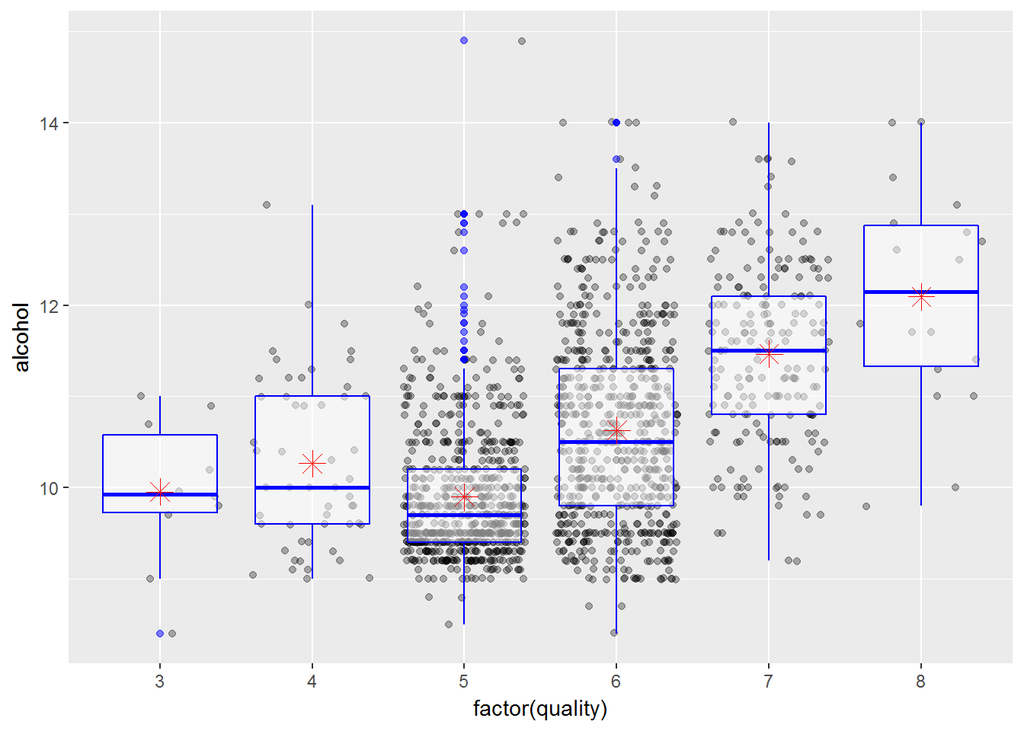

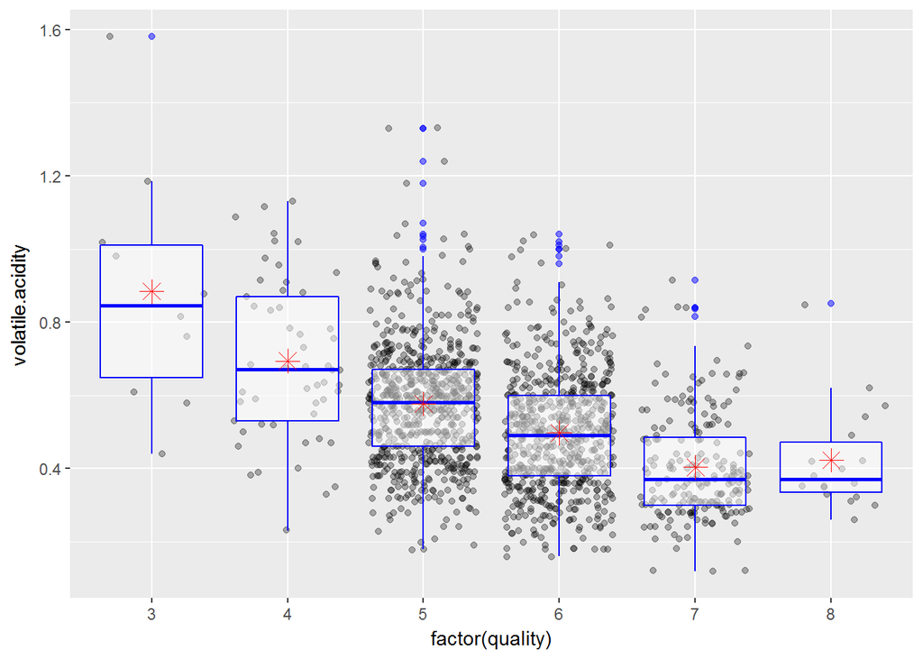

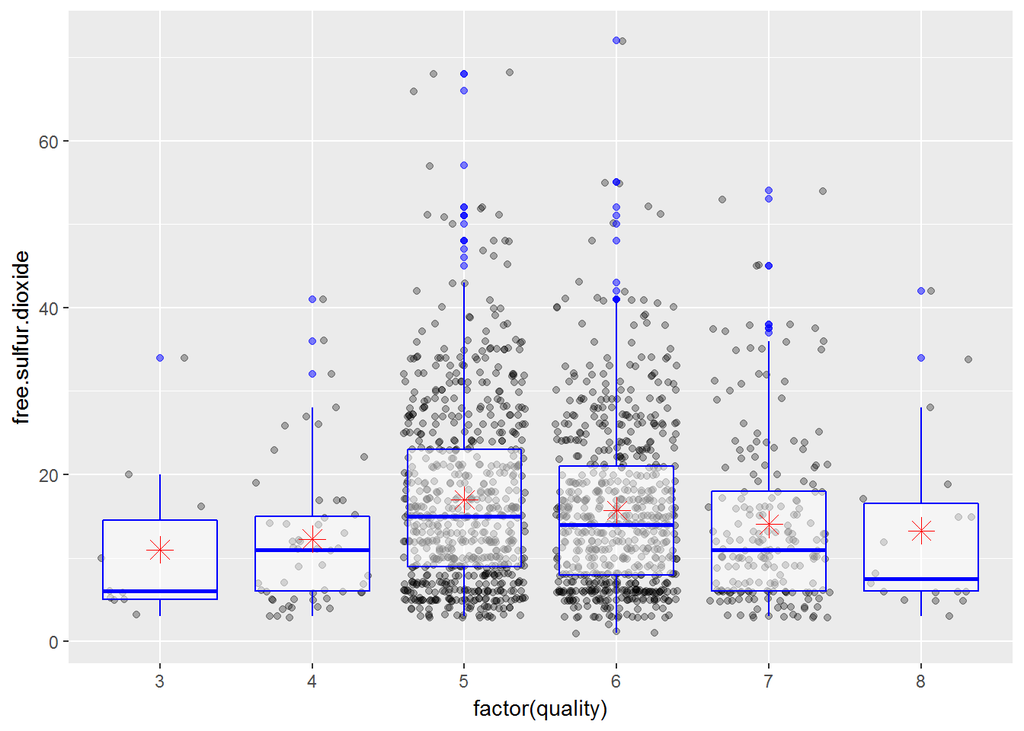

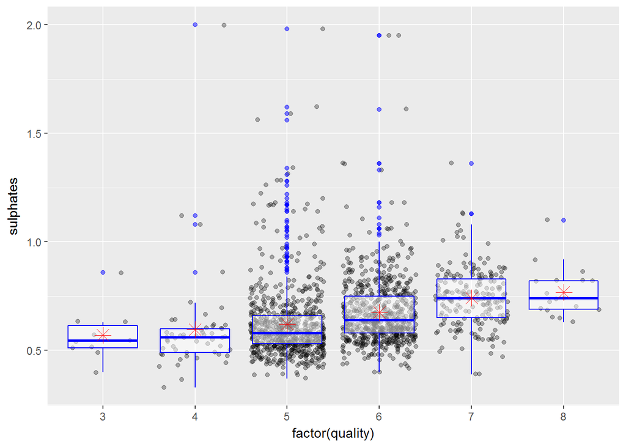

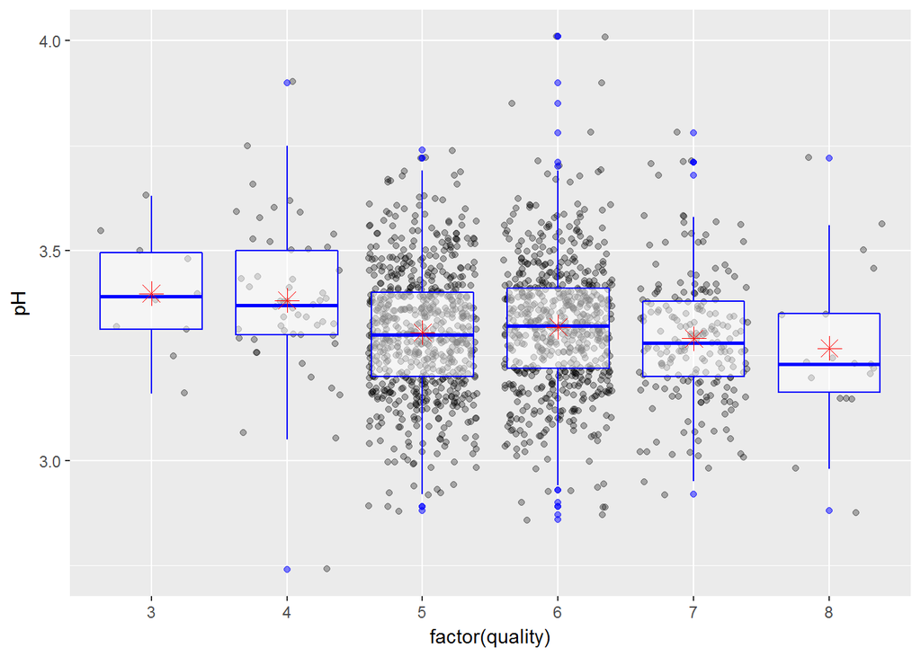

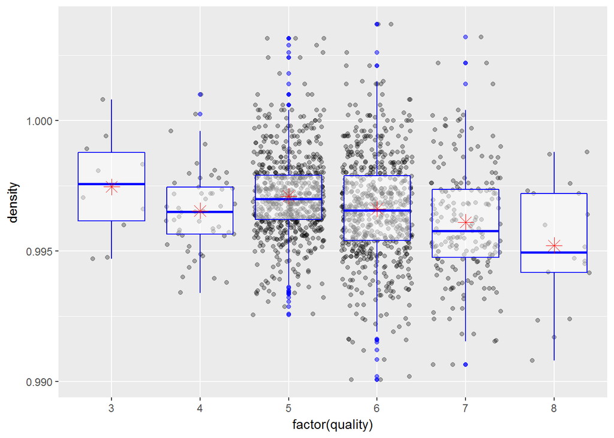

One of the most interesting variables is the quality. In the plot above, I compare this features with the other. We can see thanks to the box plot the distribution of every feature divided by quality.

```
## [1] -0.4961798
```

```
## [1] 0.3552834
```

```
## [1] 0.6680473
```

```
## [1] -0.3416993
```

```
## [1] -0.202288
```

```
## [1] 0.001917882
```

There is barely a correlation between residual sugar and volatile acidity, as we expected. However we can find a correlation of 0.668 between density and acidity which means that the bigger density the wine will be more acid. Alcohol and density has a inverse correlation, it means the more alcohol the less dense the wine is. It happen the same with alcohol and acidity to lesser extent.

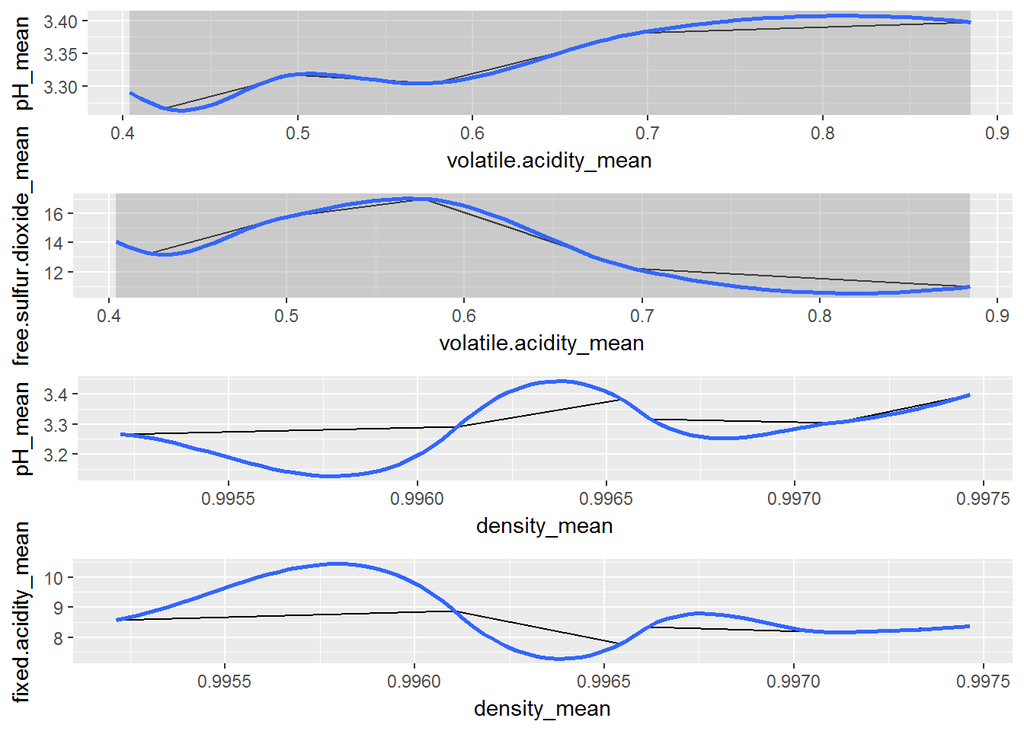

# Bivariate Analysis

### Talk about some of the relationships you observed in this part of the

investigation. How did the feature(s) of interest vary with other features in the dataset? As we have said before, there are a lot of correlations between variables. One example is acidity and density. We got a correlation of 0.67. It seems that the more dense is the wine the taste get more acid.

### Did you observe any interesting relationships between the other features

(not the main feature(s) of interest)? We can see many correlations between most of variables. For example residual sugar and density, which seems logical as the more sugar more dense. Or pH and density.

### What was the strongest relationship you found?

Density and acididity was the strongest one.

# Multivariate Plots Section

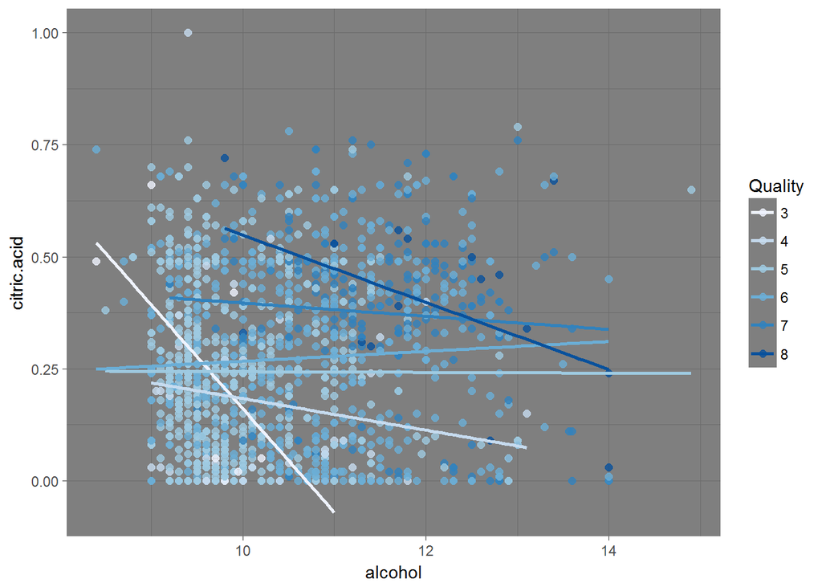

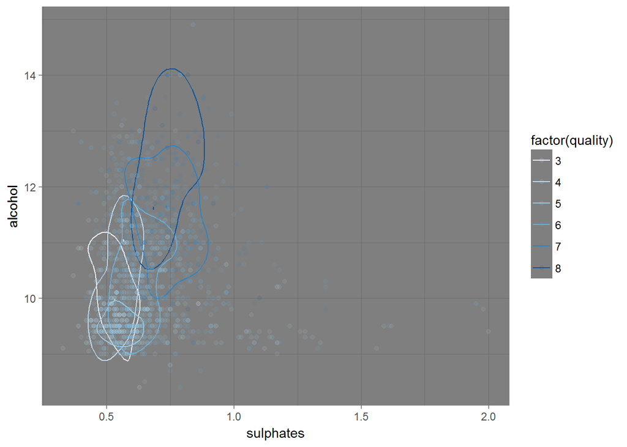

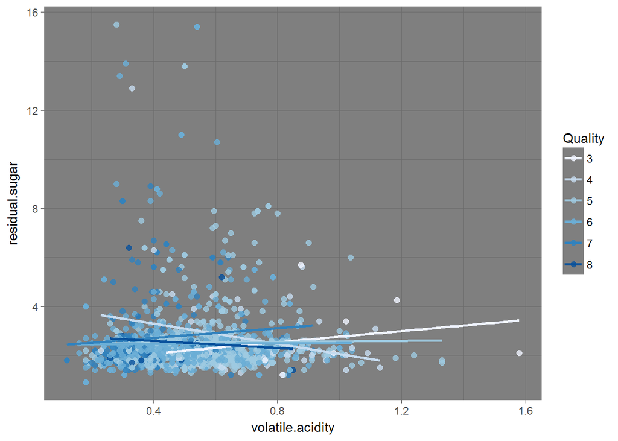

In the second graph seems clear, good quality winehas the biggest concentration of alcohol and sulphate.

# Multivariate Analysis

### Were there any interesting or surprising interactions between features?

# Final Plots and Summary

You’ve done a lot of exploration and have built up an understanding of the structure of and relationships between the variables in your dataset. Here, you will select three plots from all of your previous exploration to present here as a summary of some of your most interesting findings. Make sure that you have refined your selected plots for good titling, axis labels (with units), and good aesthetic choices (e.g. color, transparency). After each plot, make sure you justify why you chose each plot by describing what it shows.

### Plot One

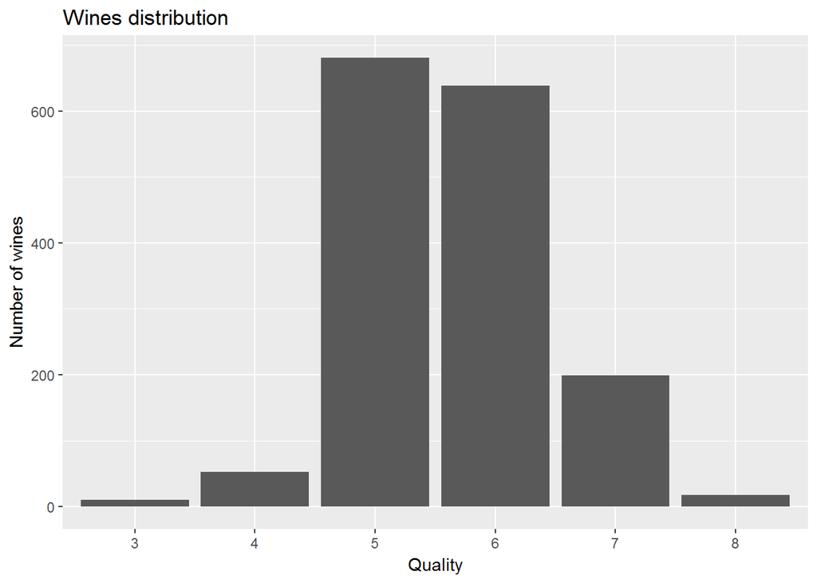

### Description One

This first graph represent the number of wines analyzed in each quality. We can see most of wines have a quality of 5 or 6, meanwhile the qualities 3, 4 and 8 have barely wines.

### Plot Two

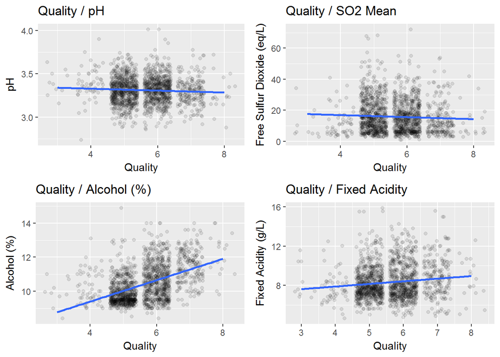

### Description Two

We can see 4 scatter plot comparing the quality with 4 different features, pH, Free Sulfur Dioxide, Alcohol and Fixed Acidity. Here we can see the most likely value for each level.

### Plot Three

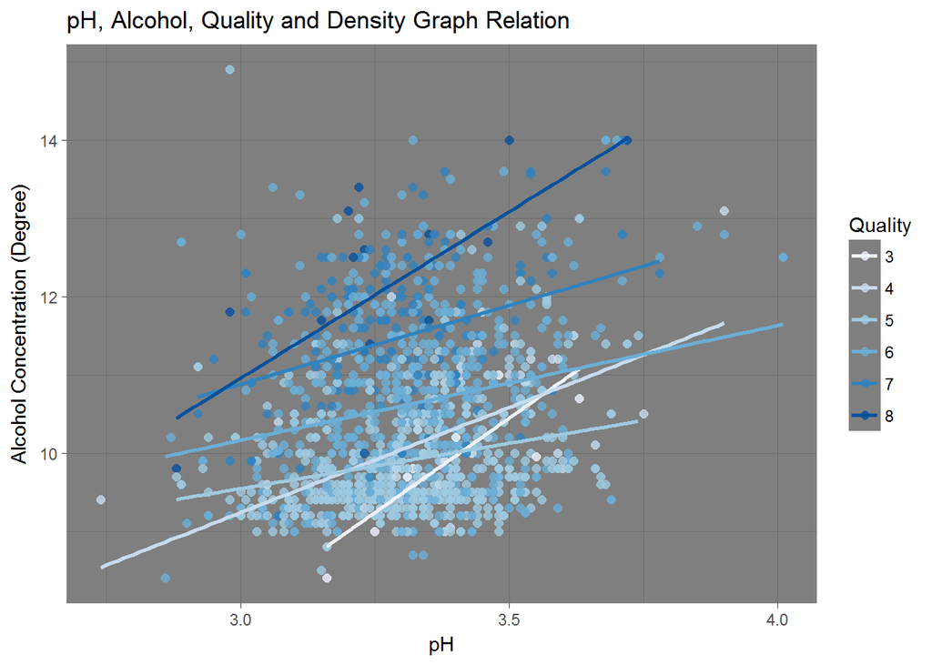

# Reflection

The wines data set contains information on 1599 wines across twelve variables from around 2009. Being an example dataset I expected clear relations between its features, however barely you can find some relations. First thing surprised me was that most of wines measured had a quality of 5 or 6 while qualities as 3, 4 or 8 have very few samples. I guess it means that most of wines has a normal quality and just a few have a high or low quality.

The most cleare relations I saw was the alcohol concentration, it is related with quality and with density.

Another thing is every feature has a perfect value indicidually, as you can see in the firsts graphs where I compare quality with every feature. However, when you have a best quality wine, these values change. It is like a lower value in alcohol can compensate a higher value in sugar.